# Measuring sediments in ocean waters

**Contents**

- Background
  - Notebook overview
  - Suspended sediments
- Notebook setup
  - Import statements
  - Dask setup
- Analysis parameters
  - Spatial and temporal window
  - Datacube query
- MODIS dataset
  - Data load
  - Data clean-up
- Coastline
  - Shape file
  - Raster mask
- TSS analysis
  - TSS calculation
  - Selected displays
  - Temporal statistics (standard))
  - Robust statistics (using Dask))
    - Approach
    - Robust functions
    - Re-chunking
    - Applying parallelised custom functions
- Extracting TSS data for further analysis
  - Time series indexing
  - Extracting to Pandas data frame

# Background

## Notebook overview

In this notebook, we use a dataset of MODIS-Aqua L2 Ocean Color data to extract a (daily) time series of total suspended sediments (TSS) for the purpose of monitoring water quality. The region of interest here is a patch of ocean waters off the coast of Sarawak, Malaysia.

In addition to providing a general overview of TSS estimation, this notebook also demonstrates a number of technical and computational aspects related to working in an open data cube environment such as EASI. In particular, this notebook will touch on the following aspects:

- deriving a raster mask of ocean pixels from a shape file of (global) coastlines
- calculation of standard temporal statistics as well as robust statistics
- application of custom functions to a Dask array (executed on a Dask cluster)
- extracting a pixel-based time series of TSS values and save it to disk for further analysis.

**A note regarding compatibility**

As stated above, this notebook makes use of a specific dataset of remote sensing data, and is applied over a given region of interest. The code below will thus not run properly if the EASI deployment used to run this notebook does not also contain a similar dataset.

Users can nonetheless investigate the outputs provided in this demonstration notebook, and also potentially modify certain variables in the code below to allow the notebook to run with a different EASI deployment (e.g. different remote sensing data, region of interest, etc.)

## Suspended sediments

In order to derive an estimate of TSS concentration (in mg/L) from the MODIS data, we need a specific formula (algorithm) that characterises the relationship between the MODIS spectral band values and the corresponding TSS measurements. The formula for the `TSS` parameter used in this notebook is as follows:

$$ \text{TSS} = \alpha \cdot \big( \text{band_ratio} \big) ^ \beta \\ \text{band_ratio} = \frac{\text{Rrs_531}}{\text{Rrs_667}} \\ \alpha = 21.238 \\ \beta = -1.272 $$

This specific model (band ratio, power function, parameters' values) was developed and fitted on the basis of ground measurements of TSS (and other water quality parameters) acquired during a field campaign in the region of interest, as part of a joint collaboration between CSIRO and Swinburne University of Technology, Sarawak, Malaysia.

# Notebook setup

## Import statements

First, let's import the key Python packages and supporting functions required in this notebook.

```python
### System
import sys, os, io
import warnings

### Datacube
import datacube
from datacube.utils import masking
from odc.algo import enum_to_bool

### Data tools
import numpy as np
import xarray as xr
import pandas as pd
from astropy.stats import sigma_clip
import cartopy.crs as ccrs
import geopandas as gpd
from shapely.geometry import Polygon
import rasterio.features
import requests, zipfile

### Plotting
%matplotlib inline
import matplotlib.pyplot as plt
from matplotlib.colors import LinearSegmentedColormap
warnings.filterwarnings("ignore", message="Tight layout not applied")

### EASI tools
sys.path.append('../scripts')
from app_utils import display_map
from notebook_utils import initialize_dask, mostcommon_crs, localcluster_dashboard, xarray_object_size

### Dask
from dask.distributed import progress, wait
```

And let's now also connect to the EASI database:

```python
dc = datacube.Datacube(app="measuring_TSS")
```

## Dask setup

Rather than loading the MODIS data into the system memory for this notebook, we will make use of Dask (Python library for parallel processing) to load up and process the dataset in a distributed fashion. This will allow us to work on very large Xarray or datacube objects that would otherwise not fit in the memory of any single compute node.

On an EASI deployment, Dask relies on the creation of a Dask Gateway cluster with associated scheduler, which is done in the following cell through the `initialize_dask` helper function.

```python
cluster, client = initialize_dask(use_gateway=True, workers=5, wait=True)

display(cluster if cluster else client)
localcluster_dashboard(client)
```

```
Creating new cluster. Please wait for this to finish.
```

```
'https://hub.csiro.easi-eo.solutions/services/dask-gateway/clusters/easihub.668a4c59177b450c8d7602f6daa1deaa/status'
```

```python
### When done with the Dask cluster, it should be shut down as follows:
# cluster.close()   # or: client.cluster.close()
# client.shutdown()
```

The Dashboard link provided above can be used to monitor the status of the Dask cluster and associated processing tasks during the execution of various code cells in the rest of this notebook.

# Analysis parameters

## Spatial and temporal window

The region of interest for this demonstration notebook is a coastal area in the South China Sea off the Malaysian state of Sarawak. The utility function `display_map` provides a convenient overview of the selected latitude / longitude extents.

```python
### Region of interest
min_longitude, max_longitude = (109.5,111.6)   # extended Sarawak coastal
min_latitude, max_latitude = (1.4,3.0)
```

```python
display_map( x = (min_longitude,max_longitude),
             y = (min_latitude,max_latitude) )
```

Make this Notebook Trusted to load map: File -> Trust Notebook

[interactive chart not shown]

For this analysis, we will use about 10 years' worth of MODIS-Ocean data.

```python
### Dates of interest:
min_date = '2010-01-01'
max_date = '2020-01-01'
```

## Datacube query

The MODIS product used in this notebook to calculate TSS is labelled `nasa_aqua_l2_oc` – this corresponds to a daily time series of NASA MODIS-Aqua L2 Ocean Color data, regridded to a WGS84 projection, and with a resolution of 0.01 $\times$ 0.01 degee.

```python
product = 'nasa_aqua_l2_oc'     # MODIS Aqua product
```

We can now initialise the main parameters of a datacube query, which we can then use to check the dataset's native projection (`mostcommon_crs`) – as we don't need to re-project the dataset to another coordinate reference system, we will simply load up the data in its native projection. We also set the `dask_chunks` query parameter to ensure the data is loaded into Dask arrays.

```python
query = { 'product': product,
          'lat': (min_latitude, max_latitude),
          'lon': (min_longitude, max_longitude),
          'time': (min_date, max_date) }

### Dataset's native projection
native_crs = mostcommon_crs(dc, query)
print(f"The dataset's native CRS is \"{native_crs}\".")

query.update({ 'output_crs': native_crs,
               'resolution': (0.01, 0.01),
               'group_by': 'solar_day',
               'dask_chunks': {'latitude': 512, 'longitude': 512} })
```

```
The dataset's native CRS is "epsg:4326".
```

Finally, loading up all MODIS bands would lead to excessive memory requirements and computational overheads. We will thus only select the bands relevant to this analysis.

The list of measurements (i.e. satellite bands and derived products) for the current product of interest can be displayed as follows.

```python
dc.list_measurements().loc[product]
```

| measurement | name | dtype | units | nodata | aliases | flags_definition | spectral_definition |
| --- | --- | --- | --- | --- | --- | --- | --- |
| aot_869 | aot_869 | int16 | 1 | -32767 | NaN | NaN | NaN |
| angstrom | angstrom | int16 | 1 | -32767 | NaN | NaN | NaN |
| rrs_412 | rrs_412 | int16 | sr^-1 | -32767 | [Rrs_412] | NaN | NaN |
| rrs_443 | rrs_443 | int16 | sr^-1 | -32767 | [Rrs_443] | NaN | NaN |
| rrs_469 | rrs_469 | int16 | sr^-1 | -32767 | [Rrs_469] | NaN | NaN |
| rrs_488 | rrs_488 | int16 | sr^-1 | -32767 | [Rrs_488] | NaN | NaN |
| rrs_531 | rrs_531 | int16 | sr^-1 | -32767 | [Rrs_531] | NaN | NaN |
| rrs_547 | rrs_547 | int16 | sr^-1 | -32767 | [Rrs_547] | NaN | NaN |
| rrs_555 | rrs_555 | int16 | sr^-1 | -32767 | [Rrs_555] | NaN | NaN |
| rrs_645 | rrs_645 | int16 | sr^-1 | -32767 | [Rrs_645] | NaN | NaN |
| rrs_667 | rrs_667 | int16 | sr^-1 | -32767 | [Rrs_667] | NaN | NaN |
| rrs_678 | rrs_678 | int16 | sr^-1 | -32767 | [Rrs_678] | NaN | NaN |
| chlor_a | chlor_a | float32 | mg m^-3 | -32767 | NaN | NaN | NaN |
| chl_ocx | chl_ocx | float32 | mg m^-3 | -32767 | NaN | NaN | NaN |
| kd_490 | kd_490 | int16 | m^-1 | -32767 | [Kd_490] | NaN | NaN |
| pic | pic | int16 | mol m^-3 | -32767 | NaN | NaN | NaN |
| poc | poc | int16 | mg m^-3 | -32767 | NaN | NaN | NaN |
| ipar | ipar | int16 | einstein m^-2 s^-1 | -32767 | NaN | NaN | NaN |
| nflh | nflh | int16 | W m^-2 um^-1 sr^-1 | -32767 | NaN | NaN | NaN |
| par | par | int16 | einstein m^-2 day^-1 | -32767 | NaN | NaN | NaN |
| l2_flags | l2_flags | int32 | 1 | -2147483648 | NaN | {'l2_flags': {'bits': [0, 1, 2, 3, 4, 5, 6, 7,... | NaN |

According to the TSS formula provided at the beginning of this notebook, we can select only those `Rrs` bands needed for the analysis. In addition, we load the layer `l2_flags` of pixel QA data, which will allow us to clean up the dataset.

```python
query.update( {'measurements': ['rrs_531', 'rrs_667', 'l2_flags']} )
query
```

```
{'product': 'nasa_aqua_l2_oc',
 'lat': (1.4, 3.0),
 'lon': (109.5, 111.6),
 'time': ('2010-01-01', '2020-01-01'),
 'output_crs': 'epsg:4326',
 'resolution': (0.01, 0.01),
 'group_by': 'solar_day',
 'dask_chunks': {'latitude': 512, 'longitude': 512},
 'measurements': ['rrs_531', 'rrs_667', 'l2_flags']}
```

# MODIS dataset

## Data load

In the next cell, we load up the MODIS dataset as directed by the `query` parameters. Note, however, that a call to `dc.load()` here does not actually trigger a transfer of data from the database to the Python / Dask environment. This is because we've instructed the data to be loaded into Dask arrays. As a result, the `dc.load()` operation becomes part of a "workflow" graph containing all the various processing steps to apply to the data (starting with loading it up from the indexed database). The various tasks in that graph are then only executed when the outputs are actually needed, e.g. when displaying the results in the notebook or writing to disk.

Because our dataset is relatively large (10 year's worth of daily data), we will try to avoid the graph potentially becoming too large and too complex, so as to minimise the load on the Dask scheduler (which enacts the communication between the Python notebook and the Dask cluster). Therefore, in the cell below, we "force" the execution of the graph when the cell's code is executed by using the `.persist()` operation on the data. The utility `progress` function then allows us to get a real-time overview of the progress of this task, and also wait for the task to be done before moving on to the next operation.

```python
### Load data
data = dc.load(**query)
data = data.persist()   # Dask data processing

progress(data, notebook=False)   # show calculation progress on Dask cluster
```

```
[########################################] | 100% Completed |  3min 33.4s
```

## Data clean-up

As usual, we need to filter out various pixels from the remote sensing dataset. These include the removal of invalid (`nodata`) pixels, as well as those affected by various pixel quality issues. In the next cell, we create the various masks required for this clean-up operation.

```python
### Mask out invalid ('no-data') pixels, for each layer
valid_mask = masking.valid_data_mask(data)
valid_mask = valid_mask.persist()   # Dask data processing

### L2_FLAGS and mask layer -- https://oceancolor.gsfc.nasa.gov/atbd/ocl2flags/
bad_pixel_defs = ( 'ATMFAIL', 'LAND', 'HIGLINT', 'HILT', 'HISATZEN',    # L3 Mask Defaults
                   'STRAYLIGHT', 'CLDICE', 'COCCOLITH', 'HISOLZEN', 'LOWLW',
                   'CHLFAIL', 'NAVWARN', 'MAXAERITER', 'CHLWARN', 'ATMWARN', 'NAVFAIL' )
good_pixel_mask = ~enum_to_bool(data['l2_flags'], bad_pixel_defs)   # boolean array
good_pixel_mask = good_pixel_mask.persist()   # Dask data processing
```

In addition, the various bands of the MODIS-Aqua dataset need to be scaled according to specific multiplicative factors and offsets. The following dictionary provides a list of the scaling parameters to apply to the data.

```python
### Lookup dictionary of scaling factors
scaling = { # modis_aqua_l2_oc
    'aot_869': {'scale': 0.0001, 'offset': 0},             # Aerosol optical thickness at 869 nm
    'angstrom': {'scale': 0.0001, 'offset': 2.5},          # Aerosol Angstrom exponent, 443 to 865 nm\
    'rrs_412': {'scale': 2e-06, 'offset': 0.05},           # Remote sensing reflectance at 412 nm
    'rrs_443': {'scale': 2e-06, 'offset': 0.05},           # Remote sensing reflectance at 443 nm
    'rrs_469': {'scale': 2e-06, 'offset': 0.05},           # Remote sensing reflectance at 469 nm
    'rrs_488': {'scale': 2e-06, 'offset': 0.05},           # Remote sensing reflectance at 488 nm
    'rrs_531': {'scale': 2e-06, 'offset': 0.05},           # Remote sensing reflectance at 531 nm
    'rrs_547': {'scale': 2e-06, 'offset': 0.05},           # Remote sensing reflectance at 547 nm
    'rrs_555': {'scale': 2e-06, 'offset': 0.05},           # Remote sensing reflectance at 555 nm
    'rrs_645': {'scale': 2e-06, 'offset': 0.05},           # Remote sensing reflectance at 645 nm
    'rrs_667': {'scale': 2e-06, 'offset': 0.05},           # Remote sensing reflectance at 667 nm
    'rrs_678': {'scale': 2e-06, 'offset': 0.05} }          # Remote sensing reflectance at 678 nm
```

The masking and scaling operations are subsequently applied on a band-by-band basis, as done in the next cell.

```python
### List of all Rrs bands
rrs_vars = [bb for bb in list(data.variables) if bb.lower().startswith('rrs')]

### Data masking & scaling
for ii,vv in enumerate(rrs_vars):   # enumerate Rrs layers

    # Apply valid + good pixel mask, and apply scaling
    data[vv] = data[vv].where(valid_mask[vv] & good_pixel_mask) * scaling[vv]['scale'] + scaling[vv]['offset']

    # Create mask to remove all pixels with value below 0.0 in any Rrs band
    if ii==0: rrs_mask = ( data[vv]>=0 )
    else: rrs_mask = np.logical_and(rrs_mask, data[vv]>=0)

### Apply mask and remove empty time slices
data = data.where(rrs_mask)
data = data.persist()   # Dask data processing

progress(data, notebook=False)   # show calculation progress on Dask cluster
```

```
[########################################] | 100% Completed | 15.0s
```

```python
### Dimensions of dataset
print( data.dims )
print( xarray_object_size(data) )
```

```
Frozen({'time': 3420, 'latitude': 160, 'longitude': 210})
Dataset size: 2.57 GB
```

And finally, we can remove any time slice in the dataset that does not contain at least one valid (non-`NaN`) pixel, as a result of the above operations.

```python
data = data.dropna('time', how='all')
data = data.persist()   # Dask data processing

progress(data, notebook=False)   # show calculation progress on Dask cluster
```

```
[########################################] | 100% Completed |  2.6s
```

```python
### Dimensions of dataset
print( data.dims )
print( xarray_object_size(data) )
```

```
Frozen({'time': 2374, 'latitude': 160, 'longitude': 210})
Dataset size: 1.78 GB
```

We can now inspect the resulting data object, e.g. by displaying one of the `Rrs` bands:

```python
data.rrs_531
```

```
<xarray.DataArray 'rrs_531' (time: 2374, latitude: 160, longitude: 210)>
dask.array<getitem, shape=(2374, 160, 210), dtype=float64, chunksize=(1, 160, 210), chunktype=numpy.ndarray>
Coordinates:
  * time         (time) datetime64[ns] 2010-01-01T05:50:01.248000 ... 2019-12...
  * latitude     (latitude) float64 1.405 1.415 1.425 ... 2.975 2.985 2.995
  * longitude    (longitude) float64 109.5 109.5 109.5 ... 111.6 111.6 111.6
    spatial_ref  int32 4326
```

From this, we can gather that the pre-processed MODIS data is available as a Dask array with 160 latitude pixels, 210 longitude pixels, and about 2400 (approximately daily) time steps. In this data object, each Dask chunk has a size `(1,160,210)` in the `time`, `latitude` and `longitude` dimensions.

# Coastline

To improve the plots further below in this notebook, we will include a mask of the land areas in the region of interest. This mask can be derived, for instance, from a shape file of coastline data.

## Shape file

The [Global Self-consistent, Hierarchical, High-resolution Geography Database](http://www.soest.hawaii.edu/pwessel/gshhg/) website provides a shape file dataset containing the [NOAA World Vector Shorelines](https://shoreline.noaa.gov/data/datasheets/wvs.html). In the following cell, in case this hasn't been done already, we download this vector file (to memory), extract the relevant files from it, and save them to disk into the `ancillary_data` folder.

```python
url = r"https://www.ngdc.noaa.gov/mgg/shorelines/data/gshhg/latest/gshhg-shp-2.3.7.zip"

shp_file = './ancillary_data/GSHHS_shp/i/GSHHS_i_L1.shp'   # file of coastline data, whole world, intermediate resolution
shx_file = './ancillary_data/GSHHS_shp/i/GSHHS_i_L1.shx'

if not os.path.isfile(shp_file) and not os.path.isfile(shx_file):
    request = requests.get(url)
    file = zipfile.ZipFile(io.BytesIO(request.content))

    file.extract('GSHHS_shp/i/GSHHS_i_L1.shp', path='./ancillary_data')
    file.extract('GSHHS_shp/i/GSHHS_i_L1.shx', path='./ancillary_data');
```

Then, we can extract the vector information over the region of interest from the downloaded shape file:

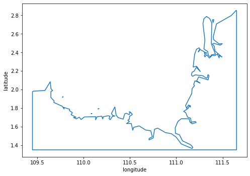

```python
buf = 0.05   # some buffer around AOI
bb = ( min_longitude-buf, min_latitude-buf,    # AOI bounding box
       max_longitude+buf, max_latitude+buf )

### All polygons over AOI
shp_poly = gpd.read_file( shp_file, bbox=bb )

### Extract vector points for AOI
polygon = Polygon([ (bb[0], bb[1]), (bb[0], bb[3]), (bb[2], bb[3]),
                    (bb[2], bb[1]), (bb[0], bb[1]) ])
shp_poly = gpd.clip(shp_poly, polygon)

### Plot
shp_poly.boundary.plot(figsize=(8,8))
plt.xlabel('longitude'); plt.ylabel('latitude');
```

## Raster mask

We can now create a raster mask of the land pixels from the vector data. The code below iterates over the polygons in the shapefile (in case multiple polygons are available), setting the raster mask values to 1.0 for all the pixels corresponding to the footprint of each polygon, and 0.0 otherwise.

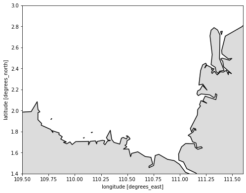

```python
mask = rasterio.features.rasterize( ((feature['geometry'], 1) for feature in shp_poly.iterfeatures()),
                                    out_shape = (data.dims['latitude'],data.dims['longitude']),
                                    transform = data.affine )

### Convert the mask (numpy array) to an Xarray DataArray
mask = xr.DataArray(mask, coords=(data.latitude, data.longitude))
mask = mask.where(mask==1)   # replace 0's with NaN's

### Plot
cmp = LinearSegmentedColormap.from_list("cmp", ["gainsboro", "gainsboro"])   # "dummy" colormap for greyed out land pixels

fig = plt.figure(figsize=(8,8))
mask.plot(add_colorbar=False, cmap=cmp);
shp_poly.boundary.plot(ax=fig.axes[0], color='black');
```

# TSS analysis

## TSS calculation

As per the formula provided at the start of this notebook, TSS values can be calculated for each pixel in the time series on the basis of the selected MODIS bands.

```python
band_ratio = data['rrs_531'] / data['rrs_667']
data_tss = 21.238 * pow(band_ratio, -1.272)

data_tss = data_tss.persist()
progress(data_tss, notebook=False)
```

```
[########################################] | 100% Completed |  1.9s
```

## Selected displays

For insight, let's take a look at the TSS data at a few selected time points.

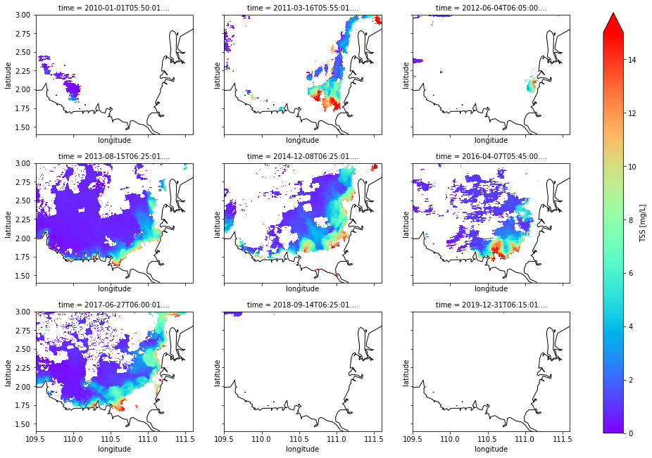

```python
tmp = np.linspace(1, data_tss.sizes['time'], 9, dtype='int') - 1   # some selected time slices to display

### Main plot
pp = data_tss[tmp].plot( col='time', col_wrap=3, cmap='rainbow',
                         add_labels=False, figsize=(17,11), vmax=15,
                         subplot_kws = dict(projection=ccrs.PlateCarree()),
                         transform = ccrs.PlateCarree(),
                         cbar_kwargs = dict(label="TSS [mg/L]") )

### Coastline and axes on each subplot
for ax in pp.axes.flat:
    shp_poly.boundary.plot(ax=ax, color='black', linewidth=1);
    # mask.plot(ax=ax, add_colorbar=False, cmap=cmp)   # removes 'time=...' titles!
    ax.set_xlabel('longitude'); ax.set_xticks(ax.get_xticks())
    ax.set_ylabel('latitude'); ax.set_yticks(ax.get_yticks())
    ax.set_extent([min_longitude, max_longitude, min_latitude, max_latitude], crs=ccrs.PlateCarree());
```

While these "daily" TSS plots can be insightful, the abundance of missing data and time slices make for a difficult assessment of the results. One approach to circumvent this is to first aggregate the data over coarser time spans, and then display the average TSS over these periods.

```python
data_tss_quarter = data_tss.resample(time="QS-JAN").mean()   # aggregation over each quarter
data_tss_quarter = data_tss_quarter.persist()

progress(data_tss_quarter, notebook=False)
```

```
[########################################] | 100% Completed |  3.2s
```

Then, as done before for the daily time series, we can select a few of the resulting quarters and plot their respective (temporally averaged) TSS maps.

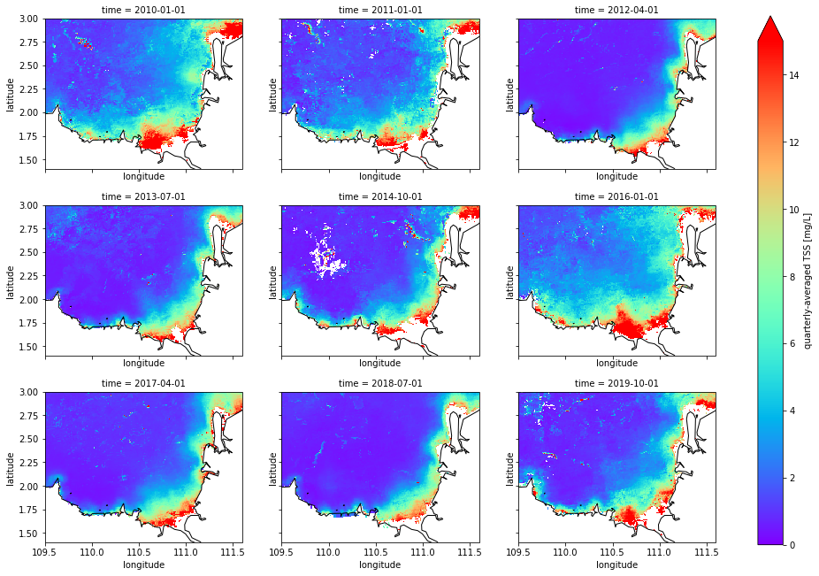

```python
tmp = np.linspace(1, data_tss_quarter.sizes['time'], 9, dtype='int') - 1   # some selected time slices to display

### Main plot
pp = data_tss_quarter[tmp].plot( col='time', col_wrap=3, cmap='rainbow',
                                 add_labels=False, figsize=(17,11), vmax=15,
                                 subplot_kws = dict(projection=ccrs.PlateCarree()),
                                 transform = ccrs.PlateCarree(),
                                 cbar_kwargs = dict(label="quarterly-averaged TSS [mg/L]") )

### Coastline and axes on each subplot
for ax in pp.axes.flat:
    shp_poly.boundary.plot(ax=ax, color='black', linewidth=1);
    # mask.plot(ax=ax, add_colorbar=False, cmap=cmap1)   # removes 'time=...' titles!
    ax.set_xlabel('longitude'); ax.set_xticks(ax.get_xticks())
    ax.set_ylabel('latitude'); ax.set_yticks(ax.get_yticks())
    ax.set_extent([min_longitude, max_longitude, min_latitude, max_latitude], crs=ccrs.PlateCarree());
```

## Temporal statistics (standard)

The overall TSS mean across the entire time series, for each pixel, can be easily calculated as follows:

```python
data_tss_mean = data_tss.mean('time')   # standard mean over entire time series
data_tss_mean = data_tss_mean.persist()
wait(data_tss_mean);
```

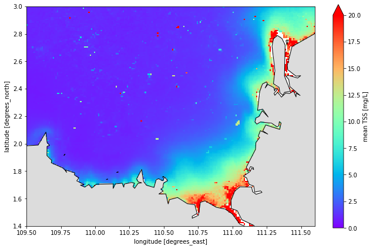

```python
### Plot
fig = plt.figure(figsize=(11,7))
data_tss_mean.plot(vmin=0.0, vmax=20.0, cmap='rainbow', cbar_kwargs={'label':'mean TSS [mg/L]'});

shp_poly.boundary.plot(ax=fig.axes[0], color='black', linewidth=1);
mask.plot(ax=fig.axes[0], add_colorbar=False, cmap=cmp);
```

This map provides an overview of the overall TSS concentrations for the region of interest and over the specified time span. In particular, it points to elevated levels of sediments along the coastline near the main river mouths, with plumes of sediments extending further out into the ocean.

Another noteworthy aspect in the above map is the presence of many (seemingly) spurious pixels showing anomalous values of TSS in the open ocean, i.e. away from the coastline.

Further investigations indicated that these spurious values correspond to pixels exhibiting negative spectral band values, which is anomalous from a physical perspective. The pre-processing we applied earlier to the dataset did indeed filter out those spurious negative-`Rrs` values, but on the basis of the data provided in the `Rrs_531` and `Rrs_667` bands only. Removing those pixels with negative spectral values in *any* `Rrs` band would here likely remove the artefacts displayed in the previous map altogether.

## Robust statistics (using Dask)

### Approach

On the basis of the current dataset (i.e., without having to go back to the beginning of this notebook, load *all* `Rrs` bands, and re-process the MODIS data to filter out the affected pixels), another approach would be to use a more robust metric of temporal average, rather than a simple `.mean()` operation. For instance, one such metric would be to calculate the *median* TSS instead.

Here, we will use another approach, which is to define our own (custom) function and apply it to our Xarray / Dask array of daily TSS data (`data_tss`). The aim here is to instruct `Xarray` to take each pixel, apply the function to the corresponding TSS time series (along the `time` dimension), and aggregate the results to produce a map with a `latitude` and a `longitude` dimension. And given the Dask cluster of compute nodes at hand, as well as the fact that the `data_tss` object actually resides in the workers' memory, we would also like this process to occur in a parallelised fashion on the cluster of distributed CPUs.

### Robust functions

In the next cell, we start by defining a `robust_mean()` function, which operates as follow on a Numpy vector `x` of input data:

1. remove `Nan`s from the data
2. remove outliers from the data using the `sigma_clip` function
3. calculate and return the (standard) mean of the filtered data (`NaN`s and outliers removed).

Further below, this function will be applied, in a parallelised fashion, to the Dask array of TSS values – essentially, `robust_mean()` will receive as input `x` the time series of TSS values for each pixel in turn. The returned value of the pixel's (robust) average TSS will then be used to build the map of average mean TSS calculated in a robust way.

In addition, we here also define another function (`robust_cv()`) to calculate the *coefficient of variation* (CV) for the same time series of TSS data (at each pixel). As shown below, the CV is simply defined as the standard deviation of the input values, divided by their mean – here again, calculated in a robust manner on the basis of the filtered vector of data.

```python
def robust_mean(x):
    xf = sigma_clip( x[~np.isnan(x)], masked=False )   # filter out NaNs and outliers
    return np.mean(xf)   # mean of data without outliers

def robust_cv(x):
    xf = sigma_clip( x[~np.isnan(x)], masked=False )   # filter out NaNs and outliers
    return np.std(xf) / np.mean(xf)   # CV of data without outliers
```

### Re-chunking

In terms of applying custom functions to a Dask array, one thing to pay particular attention to is the way the data object is chunked, i.e. the way the data is actually "scattered" in memory across the cluster of nodes. We can get a graphical representation of this chunking by simply "displaying" the data object:

```python
data_tss
```

```
<xarray.DataArray (time: 2374, latitude: 160, longitude: 210)>
dask.array<mul, shape=(2374, 160, 210), dtype=float64, chunksize=(1, 160, 210), chunktype=numpy.ndarray>
Coordinates:
  * time         (time) datetime64[ns] 2010-01-01T05:50:01.248000 ... 2019-12...
  * latitude     (latitude) float64 1.405 1.415 1.425 ... 2.975 2.985 2.995
  * longitude    (longitude) float64 109.5 109.5 109.5 ... 111.6 111.6 111.6
    spatial_ref  int32 4326
```

Here, we see that the shape of each chunk is `(1, 160, 210)` for the `time`, `latitude` and `longitude` dimensions: each time step essentially corresponds to a *different* chunk. This representation of the data is not conducive to time series processing – extracting the TSS time series for a given pixel would require accessing the data from *all* chunks at the same time, with different chunks located in the memory of different compute nodes (leading to lots of data shuffling across the Dask scheduler).

Prior to applying our custom functions, we thus need to *re-chunk* the data to a format where each chunk contains (at least) one full / unbroken time series of TSS values. In other words, we want to remove the chunking along the time dimension, which will lead to the TSS time series for each pixel being contained in a single chunk of Dask memory. To balance this, we will also define smaller chunks along the `latitude` and `longitude` dimensions (so as to achieve roughly dimilar chunk sizes as the original Dask array).

This is achieved in the following cell by means of the `.chunk()` operation.

```python
### Re-chunk Dask array
data_tss = data_tss.chunk({'time':-1, 'latitude':5, 'longitude':5})
data_tss = data_tss.persist()
wait(data_tss);
```

```python
data_tss
```

```
<xarray.DataArray (time: 2374, latitude: 160, longitude: 210)>
dask.array<rechunk-merge, shape=(2374, 160, 210), dtype=float64, chunksize=(2374, 5, 5), chunktype=numpy.ndarray>
Coordinates:
  * time         (time) datetime64[ns] 2010-01-01T05:50:01.248000 ... 2019-12...
  * latitude     (latitude) float64 1.405 1.415 1.425 ... 2.975 2.985 2.995
  * longitude    (longitude) float64 109.5 109.5 109.5 ... 111.6 111.6 111.6
    spatial_ref  int32 4326
```

Each chunk in the `data_tss` object now contains the full time series of TSS values (2374 data points) along the `time` dimension. Our custom functions can now be applied to the data pixel-by-pixel (in a distributed manner) without the need to shuffle data from the memory of one node to another.

### Applying parallelised custom functions

In the following cell, the `robust_mean` function is applied to the dataset my making use of the `apply_ufunc()` function in `Xarray`.

```python
data_tss_RobMean = xr.apply_ufunc( robust_mean, data_tss, input_core_dims=[["time"]],
                                   dask='parallelized', vectorize=True )   # robust mean, whole time series
data_tss_RobMean = data_tss_RobMean.persist()
wait(data_tss_RobMean);
```

The Dask dashboard here provides valuable insights in order to obtain that all-satisfying (!) confirmation that our custom function has indeed been successfully applied to the data in parallel on the multiple CPUs of the Dask cluster.

The image below is a screenshot of the Dask dashboard recorded after the execution of the previous code cell – we can clearly see that the `robust_mean()` function has been vectorised and applied in parallel by all compute units, as shown by the multiple tasks labelled `vectorize_robust_mean` in the Task Stream display.

[figure not shown]

Our second custom function can now be applied in the same way to the TSS data.

```python
data_tss_robCV = xr.apply_ufunc( robust_cv, data_tss, input_core_dims=[["time"]],
                                dask='parallelized', vectorize=True )   # robust mean, whole time series
data_tss_robCV = data_tss_robCV.persist()
wait(data_tss_robCV);
```

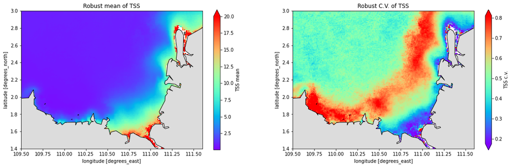

```python
### Plots
fig, (ax1,ax2) = plt.subplots(1, 2, figsize=(19,5.5))

data_tss_RobMean.plot(vmax=20, cmap='rainbow', cbar_kwargs={'label':'TSS mean'}, ax=ax1)
shp_poly.boundary.plot(ax=ax1, color='black', linewidth=1)
mask.plot(ax=ax1, add_colorbar=False, cmap=cmp)
ax1.set_title(f"Robust mean of TSS")
ax1.set_aspect('equal','box')

data_tss_robCV.plot(robust=True, cmap="rainbow", cbar_kwargs={'label':'TSS c.v.'}, ax=ax2)
shp_poly.boundary.plot(ax=ax2, color='black', linewidth=1)
mask.plot(ax=ax2, add_colorbar=False, cmap=cmp)
ax2.set_title(f"Robust C.V. of TSS");
```

The plot of robust mean values (left-hand side) is now free of the spurious pixels that were affecting the earlier map – we can thus have confidence that the `robust_mean` function has been applied as expected to the data.

And on the right-hand side, the CV map provides further insight into the temporal dynamics in the TSS dataset, highlighting a band of "hot spots" with elevated TSS variability along the coastline.

# Extracting TSS data for further analysis

## Time series indexing

At this point, a practitioner might want to extract the time series of TSS values at selected locations, display them, and potentially write them to file to be used as input to further processing or modelling work.

We demonstrate this by first selecting a few points of interest, e.g. along a transect line across the region of interest.

```python
### Some pixels along a transect
n_points = 5
pixloc_lat = np.linspace(1.76, 2.5, n_points)
pixloc_lon = np.linspace(110.85, 110.25, n_points)
```

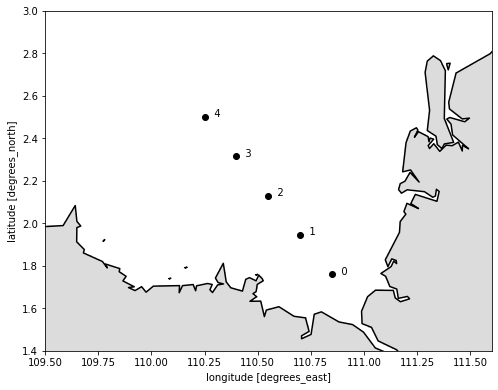

```python
### Plot
fig = plt.figure(figsize=(8,8))
plt.plot(pixloc_lon, pixloc_lat, marker='o', color='black', linestyle='none')
mask.plot(add_colorbar=False, cmap=cmp)
shp_poly.boundary.plot(ax=fig.axes[0], color='black');
[plt.text(x,y,f"{p:4d}") for p,(y,x) in enumerate(zip(pixloc_lat,pixloc_lon))];
```

We can now extract the pixels' TSS data using `Xarray`'s vectorised indexing functionality, which will retrieve data at the grid cells nearest to the target latitudes and longitudes.

```python
points_lon = xr.DataArray(pixloc_lon, dims="points")
points_lat = xr.DataArray(pixloc_lat, dims="points")

### Extract data (quarterly dataset)
points_dat = data_tss_quarter.sel(longitude=points_lon, latitude=points_lat, method="nearest")
points_dat = points_dat.dropna('time', how='all')

points_dat = points_dat.persist()
```

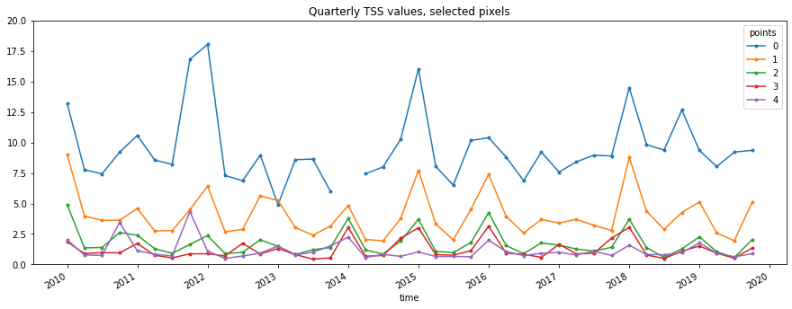

```python
### Plot
points_dat.plot.line(x='time', marker='.', figsize=(15,5), ylim=(0,20));
plt.gca().set_title("Quarterly TSS values, selected pixels");
```

Again, this plot provides a clear indication that the points further away from the coastline are less affected (lower TSS values) by the plumes of sediments coming out of the river mouth. The seasonal (cyclical) aspect of TSS values over time is also clearly evident from this type of time series plots.

## Extracting to Pandas data frame

The following code cell will extract the sampled TSS data into a Pandas data frame:

```python
### Extract to Pandas
tss_df = pd.DataFrame( data = points_dat.values,
                       index = points_dat.time.values,
                       columns = points_dat.points.values )

### (Re)set DF index
tss_df['month'] = tss_df.index.month
tss_df['year'] = tss_df.index.year
tss_df = tss_df.set_index(['year','month'])

tss_df
```

| year | month | 0 | 1 | 2 | 3 | 4 |
| --- | --- | --- | --- | --- | --- | --- |
| 2010 | 1 | 13.211155 | 8.985818 | 4.886374 | 1.861492 | 2.015349 |
|  | 4 | 7.763493 | 3.969430 | 1.366529 | 0.894101 | 0.772034 |
|  | 7 | 7.421293 | 3.624323 | 1.394278 | 0.973202 | 0.751845 |
|  | 10 | 9.206108 | 3.623667 | 2.622719 | 0.955609 | 3.445407 |
| 2011 | 1 | 10.573307 | 4.589957 | 2.390807 | 1.726759 | 1.119788 |
|  | 4 | 8.558595 | 2.743963 | 1.303132 | 0.755653 | 0.839198 |
|  | 7 | 8.198753 | 2.778104 | 0.908398 | 0.540132 | 0.703402 |
|  | 10 | 16.805457 | 4.492475 | 1.643398 | 0.872675 | 4.334920 |
| 2012 | 1 | 18.030340 | 6.426335 | 2.365187 | 0.880721 | 1.090481 |
|  | 4 | 7.290107 | 2.679360 | 0.890757 | 0.710251 | 0.501318 |
|  | 7 | 6.863688 | 2.872678 | 1.001169 | 1.732280 | 0.691469 |
|  | 10 | 8.955211 | 5.625487 | 2.020956 | 0.855284 | 0.935105 |
| 2013 | 1 | 4.897293 | 5.236786 | 1.485472 | 1.311203 | 1.513349 |
|  | 4 | 8.589918 | 3.027660 | 0.826800 | 0.810050 | 0.786350 |
|  | 7 | 8.632767 | 2.399965 | 1.214595 | 0.442408 | 1.000722 |
|  | 10 | 5.988774 | 3.147049 | 1.386355 | 0.540025 | 1.521853 |
| 2014 | 1 | NaN | 4.834885 | 3.776253 | 3.039160 | 2.237992 |
|  | 4 | 7.430876 | 2.055239 | 1.204567 | 0.682045 | 0.575877 |
|  | 7 | 7.987751 | 1.933896 | 0.853495 | 0.739643 | 0.823565 |
|  | 10 | 10.267379 | 3.773683 | 1.928427 | 2.155324 | 0.665952 |
| 2015 | 1 | 16.015635 | 7.715364 | 3.704786 | 3.001970 | 1.032981 |
|  | 4 | 8.044689 | 3.318025 | 1.070045 | 0.809935 | 0.652129 |
|  | 7 | 6.495661 | 2.014010 | 0.977305 | 0.761061 | 0.660460 |
|  | 10 | 10.158055 | 4.512365 | 1.793840 | 1.136081 | 0.638796 |
| 2016 | 1 | 10.388586 | 7.381463 | 4.246861 | 3.141896 | 1.983324 |
|  | 4 | 8.803010 | 3.950553 | 1.549667 | 0.927399 | 1.057009 |
|  | 7 | 6.868652 | 2.579357 | 0.890340 | 0.840584 | 0.729555 |
|  | 10 | 9.209703 | 3.686836 | 1.766494 | 0.582569 | 0.918006 |
| 2017 | 1 | 7.573679 | 3.398751 | 1.587837 | 1.655092 | 0.991303 |
|  | 4 | 8.407258 | 3.698213 | 1.266298 | 0.875094 | 0.791369 |
|  | 7 | 8.953346 | 3.211324 | 1.103297 | 0.917253 | 1.090585 |
|  | 10 | 8.889795 | 2.779617 | 1.405845 | 2.161083 | 0.738197 |
| 2018 | 1 | 14.470368 | 8.756303 | 3.703369 | 3.048487 | 1.582192 |
|  | 4 | 9.820178 | 4.373638 | 1.387301 | 0.783117 | 0.818500 |
|  | 7 | 9.371621 | 2.872994 | 0.571741 | 0.487801 | 0.803111 |
|  | 10 | 12.655064 | 4.260394 | 1.275529 | 1.084294 | 0.976738 |
| 2019 | 1 | 9.341593 | 5.126732 | 2.262430 | 1.516661 | 1.770506 |
|  | 4 | 8.019524 | 2.578684 | 1.049025 | 0.917233 | 0.930774 |
|  | 7 | 9.206095 | 1.947323 | 0.566595 | 0.526048 | 0.629861 |
|  | 10 | 9.352054 | 5.076395 | 2.026925 | 1.340652 | 0.880742 |

We can also "re-format" the data frame into a long (as opposed to wide) format:

```python
tss_df = tss_df.stack(dropna=False).rename_axis(['year','month','point'])
tss_df = pd.DataFrame(tss_df).rename(columns={0:'TSS'})
tss_df
```

| year | month | point | TSS |
| --- | --- | --- | --- |
| 2010 | 1 | 0 | 13.211155 |
|  |  | 1 | 8.985818 |
|  |  | 2 | 4.886374 |
|  |  | 3 | 1.861492 |
|  |  | 4 | 2.015349 |
| ... | ... | ... | ... |
| 2019 | 10 | 0 | 9.352054 |
|  |  | 1 | 5.076395 |
|  |  | 2 | 2.026925 |
|  |  | 3 | 1.340652 |
|  |  | 4 | 0.880742 |

200 rows × 1 columns

And finally, saving the data (e.g. to `.csv` or `.pkl` file) can be achieved with the following code:

```python
### Uncomment if needed:
# tss_df.to_csv('./TSS_pixel_data.csv')
# tss_df.to_pickle(path='./TSS_pixel_data.pkl')
```

```python
### End notebook
```